# R Notebook

```r
library(conditionalsads)
```

This analysis will also source functions from `meteR` and `feasiblesads`.

## 1. Generate toy data

Generate toy dataset that captures 4 scenarios:

1. S and N are the same for control and manipulated communities, and both are drawn from the statistical constraint.
2. S and N change with manipulation, but both are drawn from their respective constraints.
3. S and N remain the same, but the manipulated community is drawn from a near-uniform distribution rather than the statistical constraint.
4. S and N change, and the manipulated community is drawn from a near-uniform distribution.

Within each scenario there are `nsamples` communities in each treatment group. The control communities always have `ctrl_s` species and `ctrl_n` individuals. For scenarios 2 and 4, the treatment communities have approximately 80% of the species and individuals as the control communities.

```r
toy_mete = make_toy_data(constraint = "METE", nsamples = 10, ctrl_s = 5, ctrl_n = 100)
str(toy_mete)
```

```
## 'data.frame':    80 obs. of  7 variables:
##  $ h     : Factor w/ 4 levels "h1","h2","h3",..: 1 1 1 1 1 1 1 1 1 1 ...
##  $ trtmnt: Factor w/ 2 levels "control","treatment": 1 1 1 1 1 1 1 1 1 1 ...
##  $ 1     : num  1 1 1 1 2 2 1 1 1 1 ...
##  $ 2     : num  1 2 3 3 4 5 1 3 5 2 ...
##  $ 3     : num  2 23 5 26 12 8 10 15 22 5 ...
##  $ 4     : num  2 28 5 35 35 9 42 33 22 18 ...
##  $ 5     : num  94 46 86 35 47 76 46 48 50 74 ...
```

```r
head(toy_mete)
```

|  | h | trtmnt | 1 | 2 | 3 | 4 | 5 |
| --- | --- | --- | --- | --- | --- | --- | --- |
| 1 | h1 | control | 1 | 1 | 2 | 2 | 94 |
| 2 | h1 | control | 1 | 2 | 23 | 28 | 46 |
| 3 | h1 | control | 1 | 3 | 5 | 5 | 86 |
| 4 | h1 | control | 1 | 3 | 26 | 35 | 35 |
| 5 | h1 | control | 2 | 4 | 12 | 35 | 47 |
| 6 | h1 | control | 2 | 5 | 8 | 9 | 76 |

## 2. Generate samples from constraints

For each sample, generate `nsamples` samples from the feasible set and from the METE distribution.

**These will be the sample_sads for comparison.**

```r
nsamples <- 100

constraint_samples <- list()

for(i in 1:nrow(toy_mete)) {
  s = length(which(!is.na(toy_mete[i, 3:ncol(toy_mete)])))
  n = sum(toy_mete[i,3:ncol(toy_mete)], na.rm = T)
  this_fs <- sample_feasibleset(s = s, n = n, nsamples)
  this_mete <- sample_METE(s = s, n= n, nsamples)

  these_constraint_samples <- list(this_fs, this_mete)

  constraint_samples[[i]] <- these_constraint_samples

  rm(this_fs)
  rm(this_mete)
  rm(these_constraint_samples)
}
```

## 3. Calculate test statistics

- Empirical R2 and sample R2 compared to most-likely constraint vector.
- Empirical and sample evenness (Evar and Simpson’s) and skew.

```r
fs_r2 <- list()
mete_r2 <- list()

fs_evar <- list()
fs_simp <- list()
fs_skew <- list()

mete_evar <- list()
mete_simp <- list()
mete_skew <- list()

for(i in 1:nrow(toy_mete)) {
  s = length(which(!is.na(toy_mete[i, 3:ncol(toy_mete)])))
  n = sum(toy_mete[i,3:ncol(toy_mete)], na.rm = T)
  fs_r2[[i]] <- get_stat_list(empirical_rad = as.integer(toy_mete[i, 3:(s+2)]),
                              sampled_rads = constraint_samples[[i]][[1]],
                              stat = "r2", constraint = get_fs_ct(s, n, nsamples = nsamples))
  mete_r2[[i]] <- get_stat_list(empirical_rad = as.integer(toy_mete[i, 3:(s+2)]),
                                sampled_rads = constraint_samples[[i]][[1]],
                                stat = "r2", constraint = get_mete_prediction(s, n))

  fs_evar[[i]] <- get_stat_list(empirical_rad = as.integer(toy_mete[i, 3:(s+2)]),
                                sampled_rads = constraint_samples[[i]][[1]],
                                stat = "evar")
  fs_simp[[i]] <- get_stat_list(empirical_rad = as.integer(toy_mete[i, 3:(s+2)]),
                                sampled_rads = constraint_samples[[i]][[1]],
                                stat = "simpson")
  fs_skew[[i]] <-  get_stat_list(empirical_rad = as.integer(toy_mete[i, 3:(s+2)]),
                                sampled_rads = constraint_samples[[i]][[1]],
                                stat = "rad_skew")

  mete_evar[[i]] <- get_stat_list(empirical_rad = as.integer(toy_mete[i, 3:(s+2)]),
                                sampled_rads = constraint_samples[[i]][[2]],
                                stat = "evar")
  mete_simp[[i]] <- get_stat_list(empirical_rad = as.integer(toy_mete[i, 3:(s+2)]),
                                sampled_rads = constraint_samples[[i]][[2]],
                                stat = "simpson")
  mete_skew[[i]] <- get_stat_list(empirical_rad = as.integer(toy_mete[i, 3:(s+2)]),
                                sampled_rads = constraint_samples[[i]][[2]],
                                stat = "rad_skew")


  rm(s)
  rm(n)
}
```

## 4. Get quantiles of empirical test statistics vs. constraints

```r
fs_r2_quantile <- vapply(fs_r2, FUN = test_quantile, FUN.VALUE = 1)
fs_evar_quantile <- vapply(fs_evar, FUN = test_quantile, FUN.VALUE = 1)
fs_simp_quantile <- vapply(fs_simp, FUN = test_quantile, FUN.VALUE = 1)
fs_skew_quantile <- vapply(fs_skew, FUN = test_quantile, FUN.VALUE = 1)


mete_r2_quantile <- vapply(mete_r2, FUN = test_quantile, FUN.VALUE = 1)
mete_evar_quantile  <- vapply(mete_evar, FUN = test_quantile, FUN.VALUE = 1)
mete_simp_quantile  <- vapply(mete_simp, FUN = test_quantile, FUN.VALUE = 1)
mete_skew_quantile  <- vapply(mete_skew, FUN = test_quantile, FUN.VALUE = 1)


toy_mete <- cbind(toy_mete, fs_r2_quantile, fs_evar_quantile, fs_simp_quantile, fs_skew_quantile, mete_r2_quantile, mete_evar_quantile, mete_simp_quantile, mete_skew_quantile)

if(FALSE) {
  write.csv(toy_mete, "toy_mete_done.csv")
}
```

## 5. Compare quantiles across experimental treatments

[figure not shown]

[figure not shown]

[figure not shown]

[figure not shown]

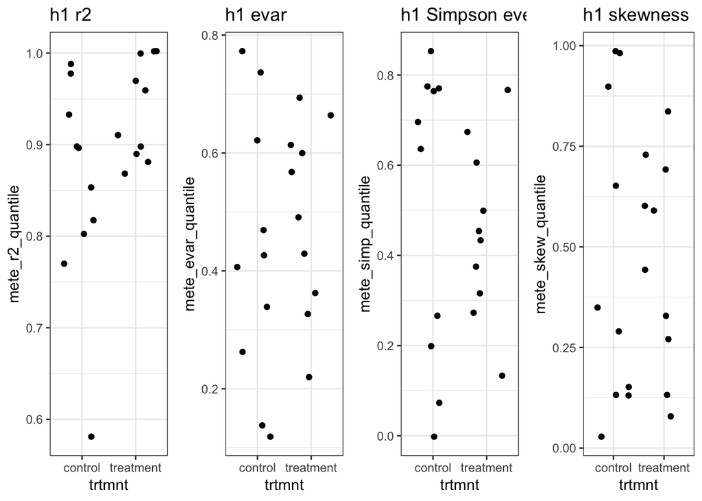

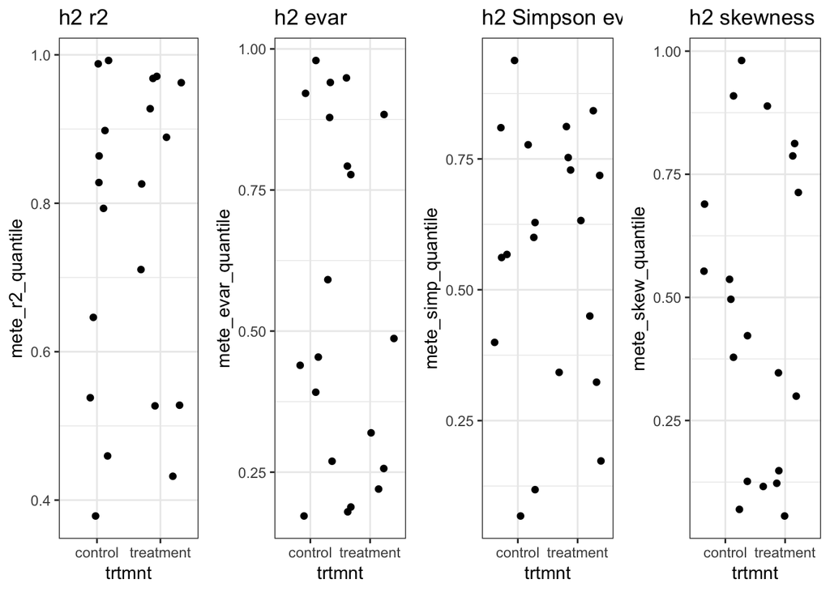

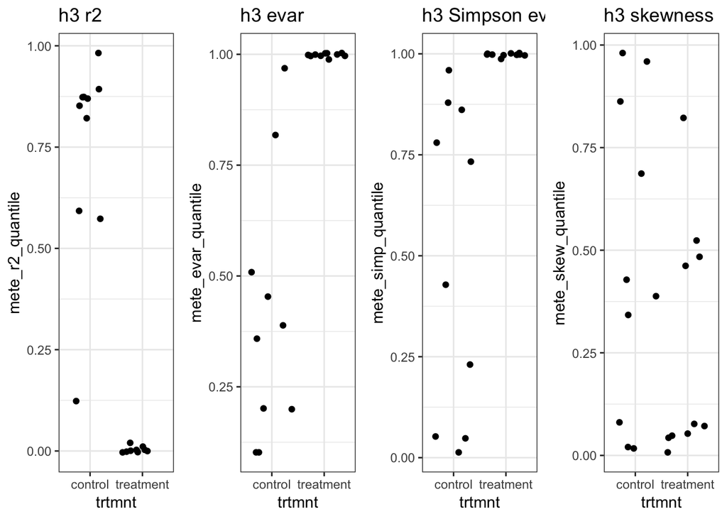

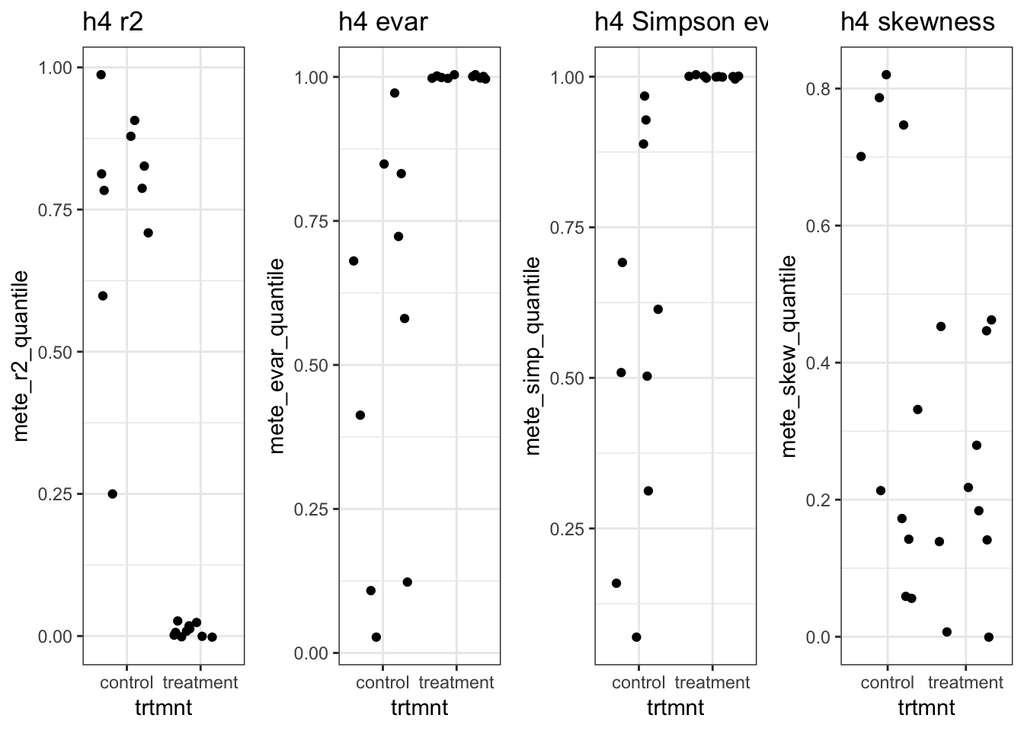

```r
for(i in 1:4) {

  this_h <- levels(toy_mete$h)[i]

  this_data <- toy_mete %>%
    dplyr::filter(h == this_h)

  r2_plot <-  ggplot(data = this_data, aes(x = trtmnt, y = mete_r2_quantile)) +
    geom_jitter(aes(x = this_data$trtmnt, y = this_data$mete_r2_quantile)) +
    ggtitle(paste0(this_h, " r2")) +
    theme_bw()

  evar_plot <-  ggplot(data = this_data, aes(x = trtmnt, y = mete_evar_quantile)) +
    geom_jitter(aes(x = this_data$trtmnt, y = this_data$mete_evar_quantile)) +
    ggtitle(paste0(this_h, " evar")) +
    theme_bw()

  simp_plot <-  ggplot(data = this_data, aes(x = trtmnt, y = mete_simp_quantile)) +
    geom_jitter(aes(x = this_data$trtmnt, y = this_data$mete_simp_quantile)) +
    ggtitle(paste0(this_h, " Simpson evenness")) +
    theme_bw()

  skew_plot <-  ggplot(data = this_data, aes(x = trtmnt, y = mete_skew_quantile)) +
    geom_jitter(aes(x = this_data$trtmnt, y = this_data$mete_skew_quantile)) +
    ggtitle(paste0(this_h, " skewness")) +
    theme_bw()

print(gridExtra::grid.arrange(r2_plot, evar_plot, simp_plot, skew_plot,
                          nrow = 1))
}
```